# Sample Size + Power

## Purpose of Today

- Understand the expected result of your experiment.
- Are you sampling sufficiently?
- Is your design optimal?

## Type I Error

- Probably of falsely rejecting a TRUE \(H_0\).

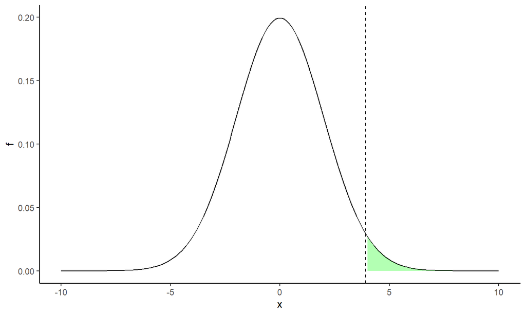

## Type II Error

- Probably of not rejecting \(H_0\), when \(H_0\) is false.

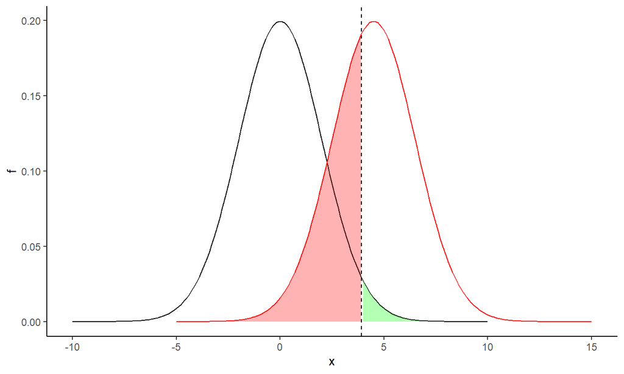

## Power

- Probability of correctly rejecting a false \(H_0\).

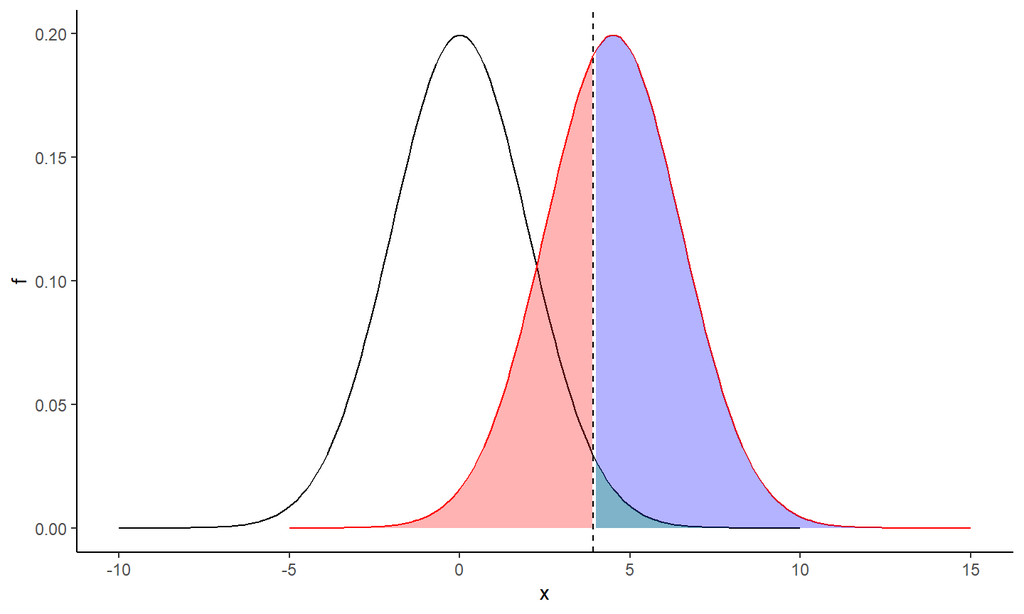

## Choosing a sample size

- More samples, smaller standard error.
- We usually have a goal of 80% power.
- Or a level of precision such as (+/- 2.5)
- If we know variance and can guess effect size, we can figure out sample size needed.
- Power is good for an experiment with a hypothesis.
- Precision is better for a field study.

## Power Depends on Effect Size

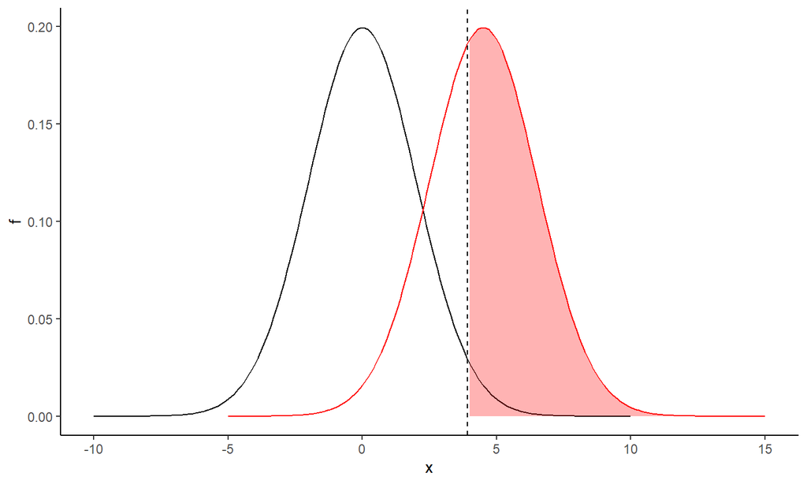

## Power Depends on Effect Size

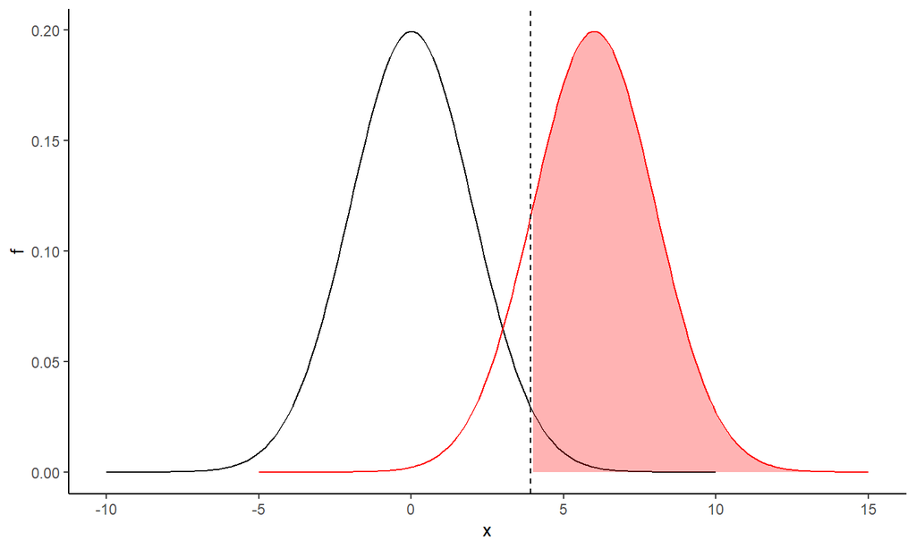

## Power Depends on Variance

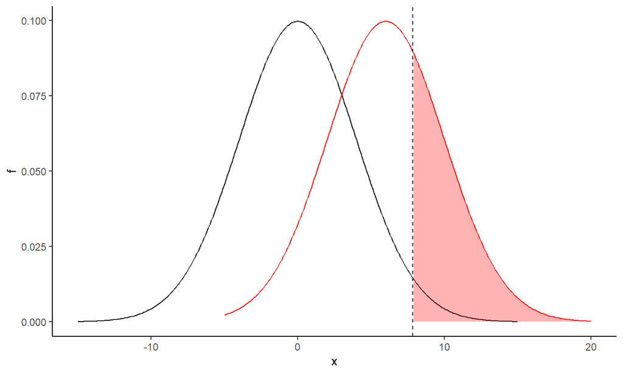

## Power of a Z test

- Sample of size \(n = 15\), with variance of \(\sigma = 3\).
- Null Hypothesis: \(\mu_0 = 0\).
- Alternative Hypothesis \(\mu_1 > 0\).
- Assume we want to detect a mean of \(\mu_1 = 2.5\).
- Significance of \(\alpha = 0.05\).

```r
  sig.level <- qnorm(0.95, 0, 3/sqrt(15))
  1-pnorm(sig.level, 2.5, 3/sqrt(15))
```

```
## [1] 0.9432474
```

```r
library(pwr)
pwr.norm.test(d = 2.5/3, n = 15,
              sig.level = 0.05, alternative = 'greater')
```

```
##
##      Mean power calculation for normal distribution with known variance
##
##               d = 0.8333333
##               n = 15
##       sig.level = 0.05
##           power = 0.9432474
##     alternative = greater
```

## T Test Version

- Things are slightly more complicated as when \(H_0\) is false.
- Need to add a non-centrality parameter to the t distribution.

```r
  sig.level <- qt(0.95, 14)
  1-pt(sig.level, df = 14, ncp = 2.5/(3/sqrt(15)))
```

```
## [1] 0.9223367
```

```r
power.t.test(n=15, delta = 2.5,  sd = 3, sig.level = 0.05,
             type = "one.sample", alternative = "one.sided")
```

```
##
##      One-sample t test power calculation
##
##               n = 15
##           delta = 2.5
##              sd = 3
##       sig.level = 0.05
##           power = 0.9223367
##     alternative = one.sided
```

## Choosing the Sample Size

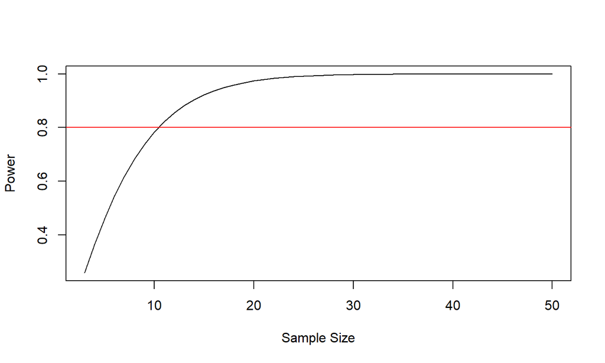

```r
pwr.n <- power.t.test(n=3:50, delta = 2.5,  sd = 3,
  sig.level = 0.05, type = "one.sample", alternative = "one.sided")
plot(pwr.n$n, pwr.n$power, type = 'l', xlab = "Sample Size", ylab = "Power")
abline(h = 0.8, col = 'red')
```